# 고급회귀분석 13장

2025-04-10

## 13.1 설명변수로 한 개의 가변수를 갖는 경우

```r
source("functions/mult_reg.R", echo = TRUE)
```

```
##
## > mult_reg = function(X, y, alpha = 0.05, coeff = TRUE) {
## +     library(glue)
## +     if (!is.matrix(X)) {
## +         stop("X는 행렬이어야 합니다.")
## +     }
## +     .... [TRUNCATED]
##
## > mult_test = function(C, m, X, X_r, y, y_r, alpha = 0.05,
## +     method = "one", coef = TRUE) {
## +     n = dim(X)[1]
## +     p = dim(X)[2]
## +     k = dim .... [TRUNCATED]
##
## > ASS_calc = function(X, y, index_sol, index_given = NA,
## +     coef = TRUE) {
## +     n = dim(X)[1]
## +     p = dim(X)[2]
## +     if (coef == TRUE) {
## +     .... [TRUNCATED]
##
## > ASS_calc_char = function(X, y, index_vec, index_sol,
## +     index_given = NA, coef = TRUE) {
## +     n = dim(X)[1]
## +     p = dim(X)[2]
## +     if (coef  .... [TRUNCATED]
##
## > standard_calc = function(X, y) {
## +     n = dim(X)[1]
## +     p = dim(X)[2]
## +     xbar = c(rep(0, p))
## +     for (j in 1:p) {
## +         xbar[j] = mean(X .... [TRUNCATED]
##
## > ortho_poly = function(X, k, coef = TRUE) {
## +     library(glue)
## +     n = dim(X)[1]
## +     p = dim(X)[2]
## +     d = X[2, 1] - X[1, 1]
## +     for (i in 1 .... [TRUNCATED]
```

```r
source("functions/reg_diagnostics.R", echo = TRUE)
```

```
##
## > outliers = function(X, y, alpha = 0.05, MSE) {
## +     library(glue)
## +     n = dim(X)[1]
## +     p = dim(X)[2]
## +     s = sqrt(MSE)
## +     one = c(rep(1,  .... [TRUNCATED]
```

```r
source("functions/var_selection.R", echo = TRUE)
```

```
##
## > source("functions/mult_reg.R", echo = FALSE)
##
## > total_subsets <- function(set) {
## +     n <- length(set)
## +     masks <- 2^(1:n - 1)
## +     res = sapply(1:(2^n - 1), function(u) set[bitwAnd(u, masks) .... [TRUNCATED]
##
## > best_subset = function(X, y) {
## +     library(glue)
## +     X = as.matrix(X)
## +     n = dim(X)[1]
## +     p = dim(X)[2]
## +     one = c(rep(1, n))
## +     In  .... [TRUNCATED]
##
## > back_eli = function(X, y, alpha_drop = 0.15, method = c("MSE",
## +     "R2", "adj_R2", "Mallow")) {
## +     library(glue)
## +     X = as.matrix(X)
## +      .... [TRUNCATED]
##
## > forward_sel = function(X, y, alpha_add = 0.15, method = c("MSE",
## +     "R2", "adj_R2", "Mallow")) {
## +     library(glue)
## +     X = as.matrix(X)
## +    .... [TRUNCATED]
##
## > stepwise_sel = function(X, y, alpha_add = 0.15, alpha_drop = 0.15,
## +     method = c("MSE", "R2", "adj_R2", "Mallow")) {
## +     library(glue)
## +     X .... [TRUNCATED]
##
## > stepwise_eli = function(X, y, alpha_add = 0.15, alpha_drop = 0.15,
## +     method = c("MSE", "R2", "adj_R2", "Mallow")) {
## +     library(glue)
## +     X .... [TRUNCATED]
```

```r
x1 = c(151, 92, 175, 31, 104, 277, 210, 120, 290, 238,
       164, 272, 295, 68, 85, 224, 166, 305, 124, 246)
x2 = c(rep(0, 10), rep(1, 10))
y = c(17, 26, 21, 30, 22, 1, 12, 19, 4, 16,
      28, 15, 11, 38, 31, 21, 20, 13, 30, 14)

X = cbind(x1, x2)

res = mult_reg(X, y, alpha = 0.05, coeff = TRUE)
```

```
##   요인    제곱합 자유도 평균제곱합      F값  F기각치
## 1 회귀 1477.1355      2 738.567770 75.72109 3.591531
## 2 잔차  165.8145     17   9.753792       NA       NA
## 3   계 1642.9500     19         NA       NA       NA
## SST = 1642.95, SSR = 1477.13553994903, SSE = 165.814460050975
## MSR = 738.567769974513, MSE = 9.75379176770439
## F_0 = 75.7210926339407, F_alpha = 3.59153056847508
```

```r
res$beta_hat
```

```
##           [,1]
## one 33.8349119
## x1  -0.1009177
## x2   7.9339526
```

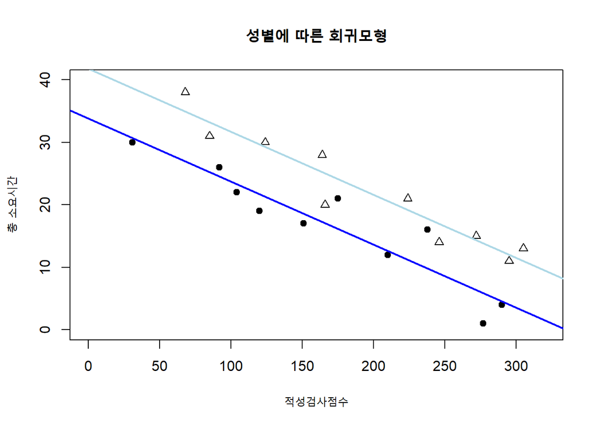

```r
# X[1:10,]
# y_hat_0 = X[1:10,] %*% res$beta_hat
# y_hat_1 = X[11:,] %*% res$beta_hat

plot(x = x1[1:10], y = y[1:10], xlab = "적성검사점수", ylab = "총 소요시간",
     main = "성별에 따른 회귀모형", col = "black", bg = "black", pch = 21, cex = 1, xlim = c(0, 320), ylim = c(0, 40))
points(x = x1[11:20], y = y[11:20], col = "black", pch = 2, cex = 1)
abline(coef = c(res$beta_hat[1] + res$beta_hat[3], res$beta_hat[2]), col = "lightblue", lwd = 2)
abline(coef = c(res$beta_hat[1], res$beta_hat[2]), col = "blue", lwd = 2)
```

```r
x1 = c(151, 92, 175, 31, 104, 277, 210, 120, 290, 238,
       164, 272, 295, 68, 85, 224, 166, 305, 124, 246)
x2 = c(rep(0, 10), rep(1, 10))
y = c(17, 26, 21, 30, 22, 1, 12, 19, 4, 16,
      28, 15, 11, 38, 31, 21, 20, 13, 30, 14)
x1_x2 = x1 * x2
X = cbind(x1, x2, x1_x2) ; X
```

```
##        x1 x2 x1_x2
##  [1,] 151  0     0
##  [2,]  92  0     0
##  [3,] 175  0     0
##  [4,]  31  0     0
##  [5,] 104  0     0
##  [6,] 277  0     0
##  [7,] 210  0     0
##  [8,] 120  0     0
##  [9,] 290  0     0
## [10,] 238  0     0
## [11,] 164  1   164
## [12,] 272  1   272
## [13,] 295  1   295
## [14,]  68  1    68
## [15,]  85  1    85
## [16,] 224  1   224
## [17,] 166  1   166
## [18,] 305  1   305
## [19,] 124  1   124
## [20,] 246  1   246
```

```r
res = mult_reg(X, y, alpha = 0.05, coeff = TRUE)
```

```
##   요인    제곱합 자유도 평균제곱합      F값  F기각치
## 1 회귀 1477.2787      3  492.42625 47.55695 3.238872
## 2 잔차  165.6713     16   10.35445       NA       NA
## 3   계 1642.9500     19         NA       NA       NA
## SST = 1642.95, SSR = 1477.27874668349, SSE = 165.671253316513
## MSR = 492.426248894496, MSE = 10.354453332282
## F_0 = 47.5569528484194, F_alpha = 3.23887151745359
```

```r
res$beta_hat
```

```
##              [,1]
## one   33.65610395
## x1    -0.09985844
## x2     8.31351564
## x1_x2 -0.00208933
```

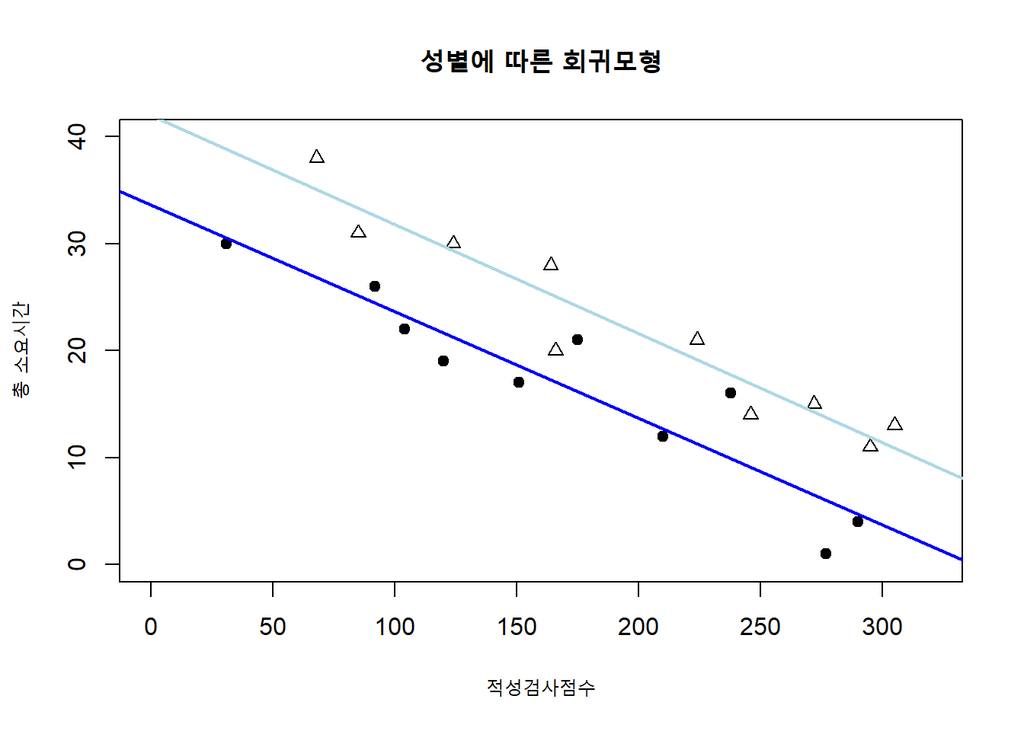

```r
plot(x = x1[1:10], y = y[1:10], xlab = "적성검사점수", ylab = "총 소요시간",
     main = "성별에 따른 회귀모형", col = "black", bg = "black", pch = 21, cex = 1, xlim = c(0, 320), ylim = c(0, 40))
points(x = x1[11:20], y = y[11:20], col = "black", pch = 2, cex = 1)
abline(coef = c((res$beta_hat[1] + res$beta_hat[3]), (res$beta_hat[2] + res$beta_hat[4])), col = "lightblue", lwd = 2)
abline(coef = c(res$beta_hat[1], res$beta_hat[2]), col = "blue", lwd = 2)
```

```r
res$beta_hat[2] + res$beta_hat[4]
```

```
## [1] -0.1019478
```

```r
res$beta_hat[2]
```

```
## [1] -0.09985844
```

```r
beta3_hat = res$beta_hat[4]
XtX_inv = solve(res$XtX) ; var_beta3_hat = t(c(0,0,0,1)) %*% XtX_inv %*% c(0,0,0,1)
t_0 = beta3_hat / sqrt(res$MSE * var_beta3_hat)
t_alpha = qt(0.025, 16, lower.tail = FALSE)
t_0 ; t_alpha
```

```
##            [,1]
## [1,] -0.1176029
```

```
## [1] 2.119905
```

## 13.3 구간별 선형회귀를 적합하는 경우

```r
x1 = c(480, 720, 570, 300, 800, 400, 340, 650)
y = c(377, 249, 355, 475, 139, 452, 440, 257)
x2 = ifelse(x1 < 500, 0, 1)
x1_x2 = (x1 - 500) * x2 ; x1_x2
```

```
## [1]   0 220  70   0 300   0   0 150
```

```r
X = cbind(x1, x1_x2)

res = mult_reg(X, y, alpha = 0.05, coeff = TRUE)
```

```
##   요인    제곱합 자유도 평균제곱합      F값  F기각치
## 1 회귀 94862.263      2 47431.1316 79.05882 5.786135
## 2 잔차  2999.737      5   599.9473       NA       NA
## 3   계 97862.000      7         NA       NA       NA
## SST = 97862, SSR = 94862.2632682252, SSE = 2999.73673177479
## MSR = 47431.1316341126, MSE = 599.947346354958
## F_0 = 79.0588239489438, F_alpha = 5.78613504334997
```

```r
res$beta_hat
```

```
##              [,1]
## one   589.5446569
## x1     -0.3953746
## x1_x2  -0.3892722
```

## 13.4 반응변수가 가변수인 경우

```r
x1 = c(8, 22, 28, 4, 19, 13, 24, 32, 9, 13,
       20, 5, 30, 11, 30, 6, 22, 12, 18, 4,
       18, 25, 6, 29, 14)
y = c(1, 1, 1, 0, 0, 1, 0, 1, 0, 0,
      1, 0, 1, 0, 1, 0, 1, 0, 0, 0,
      1, 1, 0, 0, 0)
X = cbind(x1) ; n = dim(X)[1] ; one = c(rep(1, n))

simp_res = mult_reg(X, y, alpha = 0.05, coeff = TRUE)
```

```
##   요인   제곱합 자유도 평균제곱합      F값  F기각치
## 1 회귀 1.964841      1  1.9648405 10.77226 4.279344
## 2 잔차 4.195159     23  0.1823982       NA       NA
## 3   계 6.160000     24         NA       NA       NA
## SST = 6.16, SSR = 1.96484053747774, SSE = 4.19515946252226
## MSR = 1.96484053747774, MSE = 0.182398237500968
## F_0 = 10.7722561599166, F_alpha = 4.27934430914465
```

```r
simp_res$beta_hat
```

```
##            [,1]
## one -0.09219686
## x1   0.03152825
```

```r
simp_res$MSE * solve(simp_res$XtX)
```

```
##              one            x1
## one  0.033588796 -1.557634e-03
## x1  -0.001557634  9.227691e-05
```

```r
X = cbind(one, x1)
p_hat = X %*% simp_res$beta_hat
V_hat = p_hat * (1 - p_hat) ; V_hat = as.vector(V_hat)
V_hat = diag(V_hat) ; V_hat_inv = solve(V_hat)

beta_hat_gls = solve(t(X) %*% V_hat_inv %*% X) %*% t(X) %*% V_hat_inv %*% y
beta_hat_gls
```

```
##            [,1]
## one -0.11711338
## x1   0.03267193
```

```r
solve(t(X) %*% V_hat_inv %*% X)
```

```
##               one            x1
## one  0.0127058682 -5.997223e-04
## x1  -0.0005997223  4.483488e-05
```

## 13.5 R 실습

### 13.5.1 가변수를 사용한 회귀모형 추정

$\textbf{Carseats 데이터}$ 이 데이터는 ISLR 패키지를 설치한 후 얻을 수 있으며, 400개 지점에서의 카시트 판매 정보를 담고 있다. `Carseats` 데이터에서 사용할 변수에 대한 설명은 다음과 같다.

- `Sales` : 판매량 (단위 : 1,000)
- `Price` : 각 지점에서의 카시트 가격
- `ShelveLoc` : 진열대의 등급 (Bad, Medium, Good)
- `Urban` : 도시 여부 (Yes, No)
- `US` : 미국 여부 (Yes, No)

위 데이터에서 `ShelveLoc`, `Urban`, `US`가 질적변수임을 알 수 있다. 판매량을 반응변수로 하여 중회귀모형을 적합한 결과를 살펴보자.

```r
library(ISLR)
data(Carseats)
```

```r
fit <- lm(Sales ~ ShelveLoc + Urban + US, data = Carseats)
summary(fit)
```

```
##
## Call:
## lm(formula = Sales ~ ShelveLoc + Urban + US, data = Carseats)
##
## Residuals:
##    Min     1Q Median     3Q    Max
## -6.713 -1.634 -0.019  1.738  5.823
##
## Coefficients:
##                 Estimate Std. Error t value Pr(>|t|)
## (Intercept)       4.8966     0.3398  14.411  < 2e-16 ***
## ShelveLocGood     4.6400     0.3453  13.438  < 2e-16 ***
## ShelveLocMedium   1.8168     0.2834   6.410 4.14e-10 ***
## UrbanYes          0.0999     0.2543   0.393   0.6947
## USYes             0.8506     0.2424   3.510   0.0005 ***
## ---
## Signif. codes:  0 '***' 0.001 '**' 0.01 '*' 0.05 '.' 0.1 ' ' 1
##
## Residual standard error: 2.309 on 395 degrees of freedom
## Multiple R-squared:  0.3384, Adjusted R-squared:  0.3317
## F-statistic: 50.51 on 4 and 395 DF,  p-value: < 2.2e-16
```

위 결과에서 보면 `ShelveLocGood, ShelveLocMedium, UrbanYes, USYes` 변수는 데이터에 없는 변수명인데 모형을 적합한 결과 자동으로 생성된 것을 확인할 수 있다. 이유는 R에서는 질적인 변수들에 대하여 가변수를 자동으로 생성하기 때문이다. 위 데이터를 살펴 보면 세 개의 변수 `ShelveLoc, Urban, US`는 factor 변수로 저장되어 있어 질적변수 임을 확인할 수 있다. 예를 들어, 범주가 3개인 `ShelveLoc`의 경우 2개의 가변수가 필요한데, 이 가변수가 `ShelveLocGood`과 `ShelveLocMedium`으로 표현되었음을 알 수 있다. 이를 확인하기 위해서는 다음과 같이 `contrasts()`함수를 사용할 수 있다. 아래 결과를 살펴보면 열에 나타난 `Good, Medium`이 `ShelveLoc`변수의 가변수에 해당하고, 각 범주에 따라 두 가변수가 어떤 값을 갖는지 보여 준다.

```r
contrasts(Carseats$ShelveLoc)
```

```
##        Good Medium
## Bad       0      0
## Good      1      0
## Medium    0      1
```

위 데이터에서 `Price, ShelveLoc, Urban, US`변수를 사용하여 `Sales`를 예측하기 위한 다중 회귀모형을 쓰면 다음과 같다.

$$\begin{align*}
\text{Sales}_i = \beta_0 & + \beta_1 \text{Price}_i + \beta_2
\text{ShelveLocGood}_i + \beta_3 \text{ShelveLocMedium}_i \\
& + \beta_4 \text{UrbanYes}_i + \beta_5 \text{USYes}_i +
\epsilon_i
\end{align*}$$

따라서 설명변수 진열대의 등급(`ShelveLoc`)이 판매량(sales)에 영향을 미치는 변수인지 검정하기 위해서는 $H_0 : \beta_2 = \beta_3 = 0$을 검정해야 한다. 이것은 7장에서 학습한 $C\boldsymbol{\mathbf{\beta}} = 0$의 검정으로 표현하면

$$\begin{equation*}
C\boldsymbol{\mathbf{\beta}} =
\begin{pmatrix}
0 & 0 & 1 & 0 & 0 & 0\\
0 & 0 & 0 & 1 & 0 & 0
\end{pmatrix}
\begin{pmatrix}
\beta_0 \\ \beta_1 \\ \beta_2 \\ \beta_3 \\ \beta_4 \\ \beta_5
\end{pmatrix}
=
\begin{pmatrix}
0 \\ 0
\end{pmatrix}
\end{equation*}$$

이 됨을 알 수 있고, 7장 실습에서 했던 `car`패키지의 `linearHypothesis()`함수를 사용하여 다음과 같이 검정할 수 있다.

```r
library(car)
C <- rbind(c(0,0,1,0,0,0),
           c(0,0,0,1,0,0))

fit <- lm(Sales ~ Price + ShelveLoc + Urban + US, data = Carseats)
summary(fit)
```

```
##
## Call:
## lm(formula = Sales ~ Price + ShelveLoc + Urban + US, data = Carseats)
##
## Residuals:
##     Min      1Q  Median      3Q     Max
## -5.0042 -1.2829 -0.0053  1.2471  4.6856
##
## Coefficients:
##                  Estimate Std. Error t value Pr(>|t|)
## (Intercept)     11.320199   0.514569  21.999  < 2e-16 ***
## Price           -0.058053   0.003941 -14.731  < 2e-16 ***
## ShelveLocGood    4.853360   0.278001  17.458  < 2e-16 ***
## ShelveLocMedium  1.913316   0.227969   8.393 8.61e-16 ***
## UrbanYes         0.245370   0.204700   1.199    0.231
## USYes            1.002308   0.195132   5.137 4.41e-07 ***
## ---
## Signif. codes:  0 '***' 0.001 '**' 0.01 '*' 0.05 '.' 0.1 ' ' 1
##
## Residual standard error: 1.856 on 394 degrees of freedom
## Multiple R-squared:  0.5734, Adjusted R-squared:  0.568
## F-statistic: 105.9 on 5 and 394 DF,  p-value: < 2.2e-16
```

```r
linearHypothesis(model = fit, hypothesis.matrix = C)
```

```
##
## Linear hypothesis test:
## ShelveLocGood = 0
## ShelveLocMedium = 0
##
## Model 1: restricted model
## Model 2: Sales ~ Price + ShelveLoc + Urban + US
##
##   Res.Df    RSS Df Sum of Sq      F    Pr(>F)
## 1    396 2420.8
## 2    394 1357.6  2    1063.2 154.28 < 2.2e-16 ***
## ---
## Signif. codes:  0 '***' 0.001 '**' 0.01 '*' 0.05 '.' 0.1 ' ' 1
```

### 13.5.2 교호작용효과 추정

먼저 두 질적변수에 대한 교호작용효과를 알아보기 위해, 설명변수로 `Urban, US` 변수를 선택하여 적합해 보기로 한다.

```r
fit1 = lm(Sales ~ US * Urban, data = Carseats)
summary(fit1)
```

```
##
## Call:
## lm(formula = Sales ~ US * Urban, data = Carseats)
##
## Residuals:
##    Min     1Q Median     3Q    Max
## -7.341 -1.961 -0.016  1.812  8.559
##
## Coefficients:
##                Estimate Std. Error t value Pr(>|t|)
## (Intercept)      6.4583     0.4097  15.764  < 2e-16 ***
## USYes            1.8115     0.5245   3.454 0.000612 ***
## UrbanYes         0.5396     0.4982   1.083 0.279512
## USYes:UrbanYes  -1.0983     0.6301  -1.743 0.082081 .
## ---
## Signif. codes:  0 '***' 0.001 '**' 0.01 '*' 0.05 '.' 0.1 ' ' 1
##
## Residual standard error: 2.779 on 396 degrees of freedom
## Multiple R-squared:  0.0393, Adjusted R-squared:  0.03202
## F-statistic:   5.4 on 3 and 396 DF,  p-value: 0.001191
```

위 결과에서 살펴보면 교호작용의 효과는 -1.0983으로, 유의수준 5%에서 미국내에서의 판매여부(`US`)와 판매량과의 관계가 도시여부(`Urban`)에 따라 달라진다고 말할 수 없다. 교호작용효과에 대한 그림을 직접 그리기 위해 도시가 아닌 경우 (`Urban_No`)에 미국내 판매량과 미국외 판매량을 구하고, 도시인 경우 (`Urban_Yes`)에 미국내 판매량과 미국외 판매량을 구하여 `plot()`함수를 사용하여 다음과 같이 그릴 수 있다.

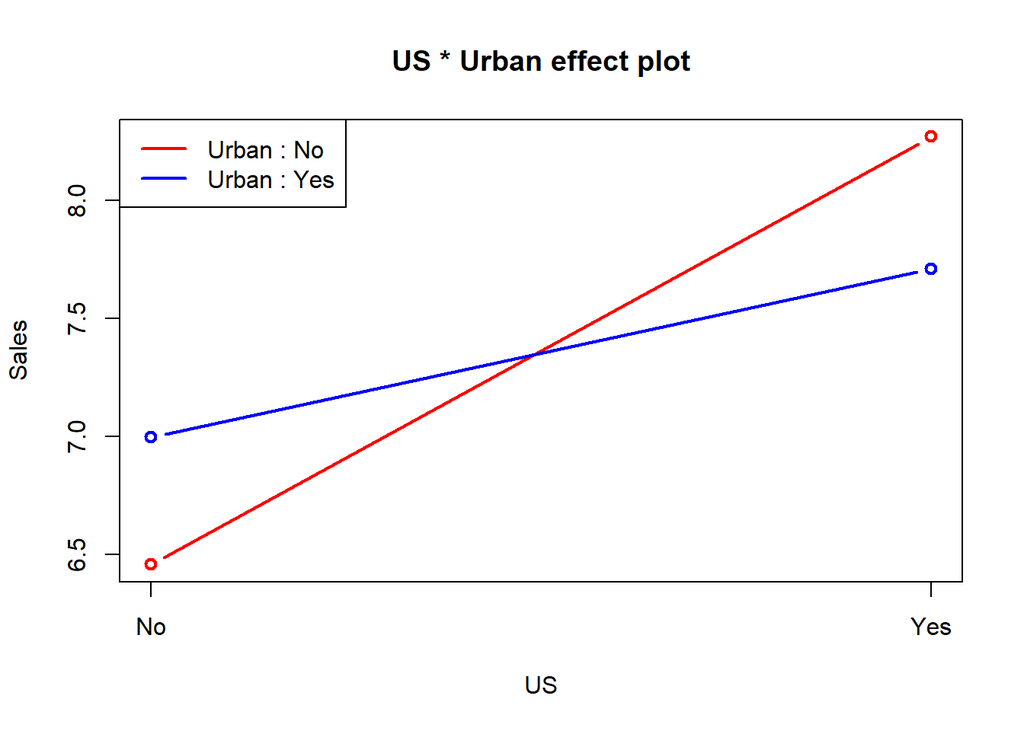

```r
coeff <- fit1$coefficients
Urban_No = matrix(0,2,1)
Urban_No[1,1] <- t(coeff) %*% c(1, 0, 0, 0) # beta_0
Urban_No[2,1] <- t(coeff) %*% c(1, 1, 0, 0) # beta_0 + beta_1

Urban_Yes = matrix(0,2,1)
Urban_Yes[1,1] <- t(coeff) %*% c(1, 0, 1, 0) # beta_0 + beta_2
Urban_Yes[2,1] <- t(coeff) %*% c(1, 1, 1, 1) # beta_0 + beta_1 + beta_2 + beta_3

plot(x = c(0, 1), y = Urban_No, type = "b", col = "red", lwd = 2,
     xlab = "US", ylab = "Sales", main = "US * Urban effect plot", xaxt = "n")
axis(side = 1, at = c(0,1), labels = c("No", "Yes"))
lines(x = c(0, 1), y = Urban_Yes, type = "b", col = "blue", lwd = 2)
legend("topleft", legend = c("Urban : No", "Urban : Yes"), col = c("red", "blue"), lwd = 2)
```

또, 교호작용효과를 적합한 회귀모형의 결과로부터 `effects` 패키지에서 `effects()`함수를 사용하면 다음과 같다.

```r
# install.packages("effects")
library(effects)
```

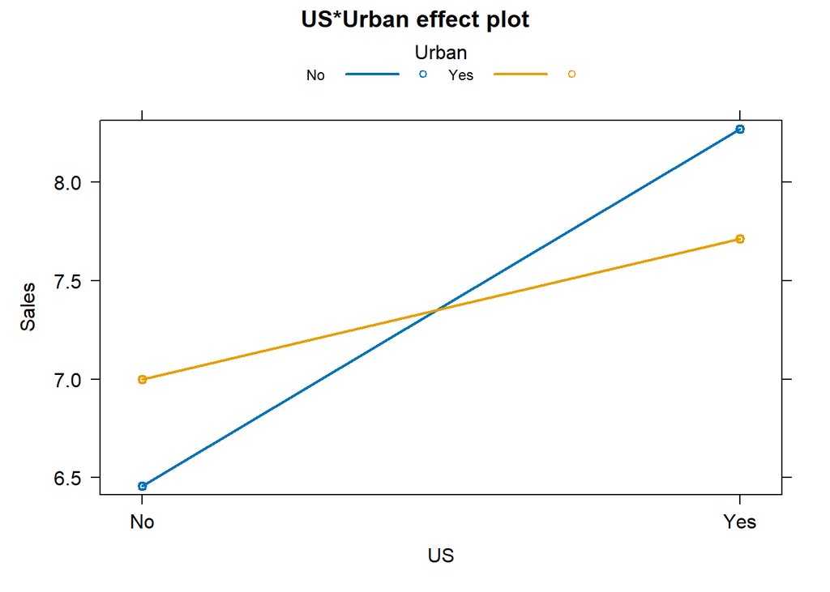

```r
a = effect(term = "US * Urban", mod = fit1)
plot(a, multiline = TRUE)
```

이제 설명변수가 연속형과 질적변수인 경우의 교호작용효과에 대해 살펴보자. 이를 위해 `Price`와 `Urban`을 설명변수로 하여 교호작용이 있는 회귀모형을 적합해 보기로 한다.

```r
fit2 = lm(Sales ~ Price * Urban, data = Carseats)
summary(fit2)
```

```
##
## Call:
## lm(formula = Sales ~ Price * Urban, data = Carseats)
##
## Residuals:
##     Min      1Q  Median      3Q     Max
## -6.5340 -1.8539 -0.0799  1.6758  7.5815
##
## Coefficients:
##                Estimate Std. Error t value Pr(>|t|)
## (Intercept)    14.60526    1.18398  12.336  < 2e-16 ***
## Price          -0.06173    0.01018  -6.067 3.06e-09 ***
## UrbanYes       -1.33702    1.40228  -0.953    0.341
## Price:UrbanYes  0.01195    0.01198   0.998    0.319
## ---
## Signif. codes:  0 '***' 0.001 '**' 0.01 '*' 0.05 '.' 0.1 ' ' 1
##
## Residual standard error: 2.535 on 396 degrees of freedom
## Multiple R-squared:    0.2,  Adjusted R-squared:  0.194
## F-statistic:    33 on 3 and 396 DF,  p-value: < 2.2e-16
```

위 결과에서 살펴보면 교호작용의 효과는 0.01195로, 유의수준 5%에서 카시트 가격(`Price`)과 카시트의 판매량(`Sales`)과의 관계는 도시여부(`Urban`)에 따라 달라진다고 말할 수 없다. 이번에도 교호작용효과에 대한 그림을 직접 그리기 위해 도시가 아닌 경우(`Urban_No`)와 도시인 경우(`Urban_Yes`)에 따라 가격과 판매량의 회귀식을 다음과 같이 그려 보았다.

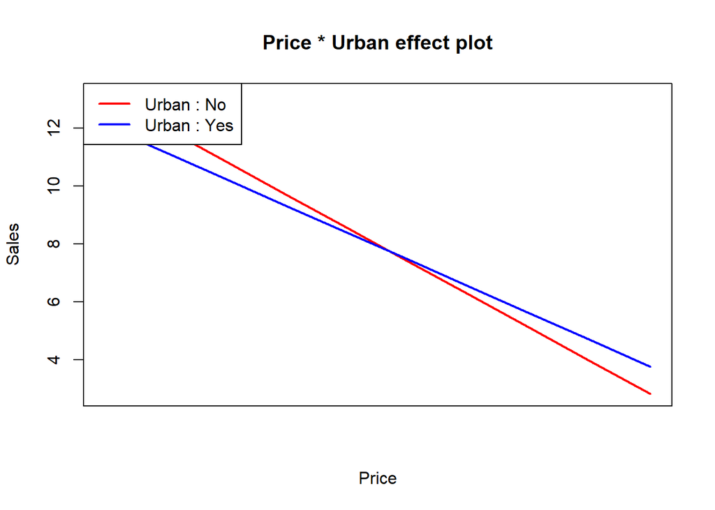

```r
coeff = fit2$coefficients
x = seq(min(Carseats$Price), max(Carseats$Price), length = 10) # grid points
Urban_No = Vectorize(function(x) t(coeff) %*% c(1, x, 0, 0)) # beta_0 + beta_1 * Price
Urban_Yes = Vectorize(function(x) t(coeff) %*% c(1, x, 1, x)) # (beta_0 + beta_2) + (beta_1 + beta_3) * Price


plot(x = x, y = Urban_No(x), type = "l", col = "red", lwd = 2,
     xlab = "Price", ylab = "Sales", main = "Price * Urban effect plot", xaxt = "n")
axis(side = 1, at = c(0,1), labels = c("No", "Yes"))
lines(x = x, y = Urban_Yes(x), type = "l", col = "blue", lwd = 2)
legend("topleft", legend = c("Urban : No", "Urban : Yes"), col = c("red", "blue"), lwd = 2)
```

또, 교호작용효과를 적합한 회귀모형의 결과로부터 `effects`패키지에서 `effects()`함수를 사용하여 다음과 같이 간단하게 그려볼 수도 있다.

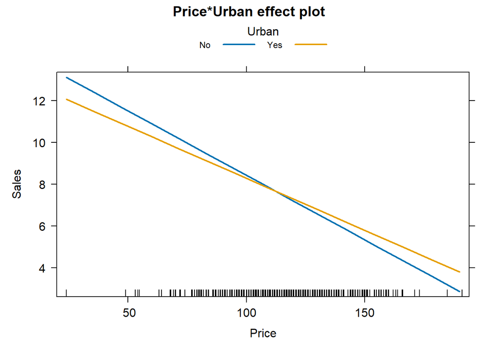

```r
a = effect(term = "Price * Urban", mod = fit2)
plot(a, multiline = TRUE)
```

## 연습문제

### 13.1

```r
x1 = c(151, 92, 175, 31, 104, 277, 210, 120, 290, 238,
       164, 272, 295, 68, 85, 224, 166, 305, 124, 246)
x2 = c(rep(0, 10), rep(1, 10))
y = c(17, 26, 21, 30, 22, 1, 12, 19, 4, 16,
      28, 15, 11, 38, 31, 21, 20, 13, 30, 14)

x_M = x1[1:10] ; x_F = x1[11:20] ; y_M = y[1:10] ; y_F = y[11:20]

X_M = cbind(x_M) ; X_F = cbind(x_F) ; X = cbind(x1)
n1 = length(x_M) ; n2 = length(x_F)


## 두 회귀직선의 검정
male_res = mult_reg(X_M, y_M, coeff = TRUE, alpha = 0.05)
```

```
##   요인   제곱합 자유도 평균제곱합      F값  F기각치
## 1 회귀 645.2253      1  645.22530 51.42533 5.317655
## 2 잔차 100.3747      8   12.54684       NA       NA
## 3   계 745.6000      9         NA       NA       NA
## SST = 745.6, SSR = 645.22529672857, SSE = 100.37470327143
## MSR = 645.22529672857, MSE = 12.5468379089288
## F_0 = 51.425331339413, F_alpha = 5.31765507157871
```

```r
female_res = mult_reg(X_F, y_F, coeff = TRUE, alpha = 0.05)
```

```
##   요인    제곱합 자유도 평균제곱합      F값  F기각치
## 1 회귀 691.60345      1 691.603450 84.73384 5.317655
## 2 잔차  65.29655      8   8.162069       NA       NA
## 3   계 756.90000      9         NA       NA       NA
## SST = 756.9, SSR = 691.603449954839, SSE = 65.2965500451607
## MSR = 691.603449954839, MSE = 8.16206875564509
## F_0 = 84.7338426886577, F_alpha = 5.31765507157871
```

```r
reduced_res = mult_reg(X, y, coeff = TRUE, alpha = 0.05)
```

```
##   요인    제곱합 자유도 평균제곱합      F값  F기각치
## 1 회귀 1170.3587      1 1170.35873 44.57648 4.413873
## 2 잔차  472.5913     18   26.25507       NA       NA
## 3   계 1642.9500     19         NA       NA       NA
## SST = 1642.95, SSR = 1170.35873145393, SSE = 472.591268546069
## MSR = 1170.35873145393, MSE = 26.2550704747816
## F_0 = 44.5764840958274, F_alpha = 4.41387341917057
```

```r
SSE_F = male_res$SSE + female_res$SSE
SSE_R = reduced_res$SSE
df_R = n1 + n2 - 2 ; df_F = (n1 - 2) + (n2 - 2)

F_0 = ((SSE_R - SSE_F)/(df_R - df_F)) / (SSE_F / df_F)
F_alpha = qf(0.05, df_R - df_F, df_F, lower.tail = FALSE)

F_0 ; F_alpha
```

```
## [1] 14.82068
```

```
## [1] 3.633723
```

```r
### 방법 1의 경우
x_M_0 = c(rep(1, n1), rep(0, n1)) ; x_F_0 = c(rep(0, n2), rep(1, n2)) ; x_M = c(x1[1:10], rep(0, n1)) ; x_F = c(rep(0, n2), x1[11:20])
X = cbind(x_M_0, x_F_0, x_M, x_F)

c1 = c(1, -1, 0, 0) ; c2 = c(0, 0, 1, -1) ; C = rbind(c1, c2) ; m = c(0, 0)
mult_test_res = mult_test(C = C, m = m, X = X, y = y, X_r = NA, y_r = NA, alpha = 0.05, method = "one", coef = FALSE)
```

```
## F_0 = 14.8206769290488, F_alpha = 3.63372346759163
```

```r
## 두 기울기의 검정
beta_1_hat = male_res$beta_hat[2] ; beta_2_hat = female_res$beta_hat[2]
var_beta_1_hat = male_res$MSE * solve(male_res$XtX)[2,2]
var_beta_2_hat = female_res$MSE * solve(female_res$XtX)[2,2]

t_0 = (beta_1_hat - beta_2_hat)/ sqrt(var_beta_1_hat + var_beta_2_hat) ; t_0
```

```
## [1] 0.117429
```

```r
t_alpha = qt(0.025, 16, lower.tail = FALSE) ; t_alpha
```

```
## [1] 2.119905
```

```r
### 방법 1의 경우
X = cbind(x_M_0, x_F_0, x_M, x_F)
c1 = c(0, 0, 1, -1); C = rbind(c1) ; m = c(0)
mult_test_res = mult_test(C = C, m = m, X = X, y = y, X_r = NA, y_r = NA, alpha = 0.05, method = "one", coef = FALSE)
```

```
## F_0 = 0.0138304485794703, F_alpha = 4.49399847766636
```

```r
t_0^2 ; t_alpha^2
```

```
## [1] 0.01378958
```

```
## [1] 4.493998
```

### 13.2

```r
x1 = c(151, 92, 175, 31, 104, 277, 210, 120, 290, 238,
       164, 272, 295, 68, 85, 224, 166, 305, 124, 246)
x2 = c(rep(0, 10), rep(1, 10))
y = c(17, 26, 21, 30, 22, 1, 12, 19, 4, 16,
      28, 15, 11, 38, 31, 21, 20, 13, 30, 14)
X = cbind(x1, x2)

mult_res = mult_reg(X, y, alpha = 0.05, coeff = TRUE)
```

```
##   요인    제곱합 자유도 평균제곱합      F값  F기각치
## 1 회귀 1477.1355      2 738.567770 75.72109 3.591531
## 2 잔차  165.8145     17   9.753792       NA       NA
## 3   계 1642.9500     19         NA       NA       NA
## SST = 1642.95, SSR = 1477.13553994903, SSE = 165.814460050975
## MSR = 738.567769974513, MSE = 9.75379176770439
## F_0 = 75.7210926339407, F_alpha = 3.59153056847508
```

```r
mult_res$beta_hat
```

```
##           [,1]
## one 33.8349119
## x1  -0.1009177
## x2   7.9339526
```

```r
beta_1_hat = mult_res$beta_hat[2]
mult_res$MSE * solve(mult_res$XtX)
```

```
##             one            x1           x2
## one  3.09288209 -1.254445e-02 -0.647969071
## x1  -0.01254445  7.431545e-05 -0.001939633
## x2  -0.64796907 -1.939633e-03  2.001382783
```

```r
mult_res$MSE * solve(mult_res$XtX)[2,2]
```

```
## [1] 7.431545e-05
```

```r
var_beta_1_hat = mult_res$MSE * solve(mult_res$XtX)[2,2]
t_alpha = qt(0.025, 20 - 2 - 1, lower.tail = FALSE)

CI_lower = beta_1_hat - t_alpha * sqrt(var_beta_1_hat)
CI_upper = beta_1_hat + t_alpha * sqrt(var_beta_1_hat)

CI_lower ; CI_upper
```

```
## [1] -0.1191057
```

```
## [1] -0.08272976
```

### 13.3

```r
x1 = c(151, 92, 175, 31, 104, 277, 210, 120, 290, 238,
       164, 272, 295, 68, 85, 224, 166, 305, 124, 246)
x2 = c(rep(0, 10), rep(1, 10))
x1x2 = x1 * x2
y = c(17, 26, 21, 30, 22, 1, 12, 19, 4, 16,
      28, 15, 11, 38, 31, 21, 20, 13, 30, 14)
X = cbind(x1, x2, x1x2)

mult_res = mult_reg(X, y, alpha = 0.05, coeff = TRUE)
```

```
##   요인    제곱합 자유도 평균제곱합      F값  F기각치
## 1 회귀 1477.2787      3  492.42625 47.55695 3.238872
## 2 잔차  165.6713     16   10.35445       NA       NA
## 3   계 1642.9500     19         NA       NA       NA
## SST = 1642.95, SSR = 1477.27874668349, SSE = 165.671253316513
## MSR = 492.426248894496, MSE = 10.354453332282
## F_0 = 47.5569528484194, F_alpha = 3.23887151745359
```

```r
beta_hat = mult_res$beta_hat ; beta_hat
```

```
##             [,1]
## one  33.65610395
## x1   -0.09985844
## x2    8.31351564
## x1x2 -0.00208933
```

```r
c1 = c(0, 1, 0, 0) ; C = rbind(c1) ; m = c(-0.3)
mult_test_res = mult_test(C = C, m = m, X = X, X_r = NA, y = y, y_r = NA, alpha = 0.1, method = "one", coef = TRUE)
```

```
## F_0 = 250.316382096944, F_alpha = 3.04810981108787
```

### 13.4

```r
x1 = c(100,125,220,205,300,255,225,175,270,170,155,190,140,290,265)
y1 = c(218,248,360,351,470,394,332,321,410,260,241,331,275,425,367)

x2 = c(105,215,270,255,175,135,200,275,155,320,190,295)
y2 = c(140,277,384,341,215,180,260,361,252,422,273,410)

n1 = length(x1) ; n2 = length(x2)
x1 = c(x1, x2) ; y = c(y1, y2)
x2 = c(rep(1, n1), rep(0, n2))
X = cbind(x1, x2)
```

#### 13.4 - (1)

```r
mult_res = mult_reg(X, y, alpha = 0.05, coeff = TRUE)
```

```
##   요인    제곱합 자유도 평균제곱합      F값  F기각치
## 1 회귀 168355.06      2 84177.5306 188.5683 3.402826
## 2 잔차  10713.68     24   446.4033       NA       NA
## 3   계 179068.74     26         NA       NA       NA
## SST = 179068.740740741, SSR = 168355.061239368, SSE = 10713.6795013731
## MSR = 84177.5306196839, MSE = 446.403312557211
## F_0 = 188.568337760477, F_alpha = 3.4028261053502
```

```r
beta_hat = mult_res$beta_hat ; beta_hat
```

```
##          [,1]
## one 27.281794
## x1   1.230741
## x2  53.129197
```

```r
## beta1의 신뢰구간
beta1_hat = beta_hat[2]
var_beta1_hat = mult_res$MSE * solve(mult_res$XtX)[2,2]
t_alpha = qt(0.025, n1 + n2 - 3, lower.tail = FALSE)

beta1_CI_lower = beta1_hat - t_alpha * sqrt(var_beta1_hat)
beta1_CI_upper = beta1_hat + t_alpha * sqrt(var_beta1_hat)
beta1_CI_lower ; beta1_CI_upper
```

```
## [1] 1.095448
```

```
## [1] 1.366034
```

```r
## beta2의 신뢰구간
beta2_hat = beta_hat[3]
var_beta2_hat = mult_res$MSE * solve(mult_res$XtX)[3,3]
t_alpha = qt(0.025, n1 + n2 - 3, lower.tail = FALSE)

beta2_CI_lower = beta2_hat - t_alpha * sqrt(var_beta2_hat)
beta2_CI_upper = beta2_hat + t_alpha * sqrt(var_beta2_hat)
beta2_CI_lower ; beta2_CI_upper
```

```
## [1] 36.18452
```

```
## [1] 70.07387
```

#### 13.4 - (2)

```r
x1x2 = x1 * x2
X = cbind(x1, x2, x1x2)

mult_res = mult_reg(X, y, alpha = 0.05, coeff = TRUE)
```

```
##   요인     제곱합 자유도 평균제곱합      F값  F기각치
## 1 회귀 169164.684      3 56388.2279 130.9493 3.027998
## 2 잔차   9904.057     23   430.6112       NA       NA
## 3   계 179068.741     26         NA       NA       NA
## SST = 179068.740740741, SSR = 169164.683817934, SSE = 9904.05692280674
## MSR = 56388.2279393114, MSE = 430.611170556815
## F_0 = 130.949292064107, F_alpha = 3.0279983823322
```

```r
beta_hat = mult_res$beta_hat ; beta_hat
```

```
##            [,1]
## one   7.5744646
## x1    1.3220488
## x2   90.3908632
## x1x2 -0.1766614
```

```r
## beta2의 신뢰구간
beta2_hat = beta_hat[3]
var_beta1_hat = mult_res$MSE * solve(mult_res$XtX)[3,3]
t_alpha = qt(0.025, n1 + n2 - 4, lower.tail = FALSE)

beta2_CI_lower = beta2_hat - t_alpha * sqrt(var_beta2_hat)
beta2_CI_upper = beta2_hat + t_alpha * sqrt(var_beta2_hat)
beta2_CI_lower ; beta2_CI_upper
```

```
## [1] 73.40712
```

```
## [1] 107.3746
```

```r
## beta3의 신뢰구간
beta3_hat = beta_hat[4]
var_beta3_hat = mult_res$MSE * solve(mult_res$XtX)[4,4]
t_alpha = qt(0.025, n1 + n2 - 4, lower.tail = FALSE)

beta3_CI_lower = beta3_hat - t_alpha * sqrt(var_beta3_hat)
beta3_CI_upper = beta3_hat + t_alpha * sqrt(var_beta3_hat)
beta3_CI_lower ; beta3_CI_upper
```

```
## [1] -0.4431826
```

```
## [1] 0.08985973
```

### 13.5

```r
x1 = c(151, 92, 175, 31, 104, 277, 210, 120, 290, 238,
       164, 272, 295, 68, 85, 224, 166, 305, 124, 246)
x2 = c(rep(0, 10), rep(1, 10)) # 남자가 0, # 여자가 1
x3 = c(0, 1, 0, 1, 1, 0, 0, 0, 0, 0,
       0, 0, 0, 1, 0, 0, 0, 0, 0, 0) # 고등학교졸이 1, 그외는 0
x4 = c(1, 0, 1, 0, 0, 0, 0, 1, 0, 0,
       0, 0, 0, 0, 1, 0, 1, 0, 1, 0) # 대학교졸이 1, 그외는 0
y = c(17, 26, 21, 30, 22, 1, 12, 19, 4, 16,
      28, 15, 11, 38, 31, 21, 20, 13, 30, 14)
X = cbind(x1,x2,x3,x4)
```

#### 13.5 - (1), (2)

```r
mult_res = mult_reg(X, y, alpha = 0.05, coeff = TRUE)
```

```
##   요인    제곱합 자유도 평균제곱합      F값  F기각치
## 1 회귀 1488.0205      4  372.00514 36.01689 3.055568
## 2 잔차  154.9295     15   10.32863       NA       NA
## 3   계 1642.9500     19         NA       NA       NA
## SST = 1642.95, SSR = 1488.02054647413, SSE = 154.92945352587
## MSR = 372.005136618532, MSE = 10.328630235058
## F_0 = 36.0168897668397, F_alpha = 3.05556827590659
```

```r
beta_hat = mult_res$beta_hat ; beta_hat
```

```
##           [,1]
## one 36.5226684
## x1  -0.1101234
## x2   7.8990531
## x3  -1.3758336
## x4  -2.4036479
```

#### 13.5 - (3)

```r
## beta3의 신뢰구간
beta3_hat = beta_hat[4]
var_beta3_hat = mult_res$MSE * solve(mult_res$XtX)[4,4] ; var_beta3_hat
```

```
## [1] 17.08443
```

```r
t_alpha = qt(0.025, 20 - 5, lower.tail = FALSE)

beta3_CI_lower = beta3_hat - t_alpha * sqrt(var_beta3_hat)
beta3_CI_upper = beta3_hat + t_alpha * sqrt(var_beta3_hat)
beta3_CI_lower ; beta3_CI_upper
```

```
## [1] -10.18582
```

```
## [1] 7.434155
```

```r
## beta4의 신뢰구간
beta4_hat = beta_hat[5]
var_beta4_hat = mult_res$MSE * solve(mult_res$XtX)[5,5] ; var_beta4_hat
```

```
## [1] 8.167908
```

```r
t_alpha = qt(0.025, 20 - 5, lower.tail = FALSE)

beta4_CI_lower = beta4_hat - t_alpha * sqrt(var_beta4_hat)
beta4_CI_upper = beta4_hat + t_alpha * sqrt(var_beta4_hat)
beta4_CI_lower ; beta4_CI_upper
```

```
## [1] -8.495235
```

```
## [1] 3.687939
```

#### 13.5 - (4)

```r
x1x2 = x1 * x2 ; x1x3 = x1 * x3 ; x1x4 = x1 * x4 ; x2x3 = x2 * x3 ; x2x4 = x2 * x4
X = cbind(x1, x2, x3, x4, x1x2, x1x3, x1x4, x2x3, x2x4)

mult_res = mult_reg(X, y, alpha = 0.05, coeff = TRUE)
```

```
##   요인    제곱합 자유도 평균제곱합      F값  F기각치
## 1 회귀 1514.3451      9  168.26057 13.08353 3.020383
## 2 잔차  128.6049     10   12.86049       NA       NA
## 3   계 1642.9500     19         NA       NA       NA
## SST = 1642.95, SSR = 1514.34509063554, SSE = 128.60490936446
## MSR = 168.260565626171, MSE = 12.860490936446
## F_0 = 13.0835258512044, F_alpha = 3.02038294702138
```

```r
beta_hat = mult_res$beta_hat ; beta_hat
```

```
##             [,1]
## one  36.63696518
## x1   -0.11186981
## x2   12.27994350
## x3   -3.42748073
## x4   -6.74634061
## x1x2 -0.01528919
## x1x3  0.01659028
## x1x4  0.03861449
## x2x3  0.02924469
## x2x4 -4.10250464
```

```r
c1 = c(0, 0, 0, 0, 0, 1, 0, 0, 0, 0)
c2 = c(0, 0, 0, 0, 0, 0, 1, 0, 0, 0)
c3 = c(0, 0, 0, 0, 0, 0, 0, 1, 0, 0)
c4 = c(0, 0, 0, 0, 0, 0, 0, 0, 1, 0)
c5 = c(0, 0, 0, 0, 0, 0, 0, 0, 0, 1)

C = rbind(c1, c2, c3, c4, c5) ; m = c(0, 0, 0, 0, 0)

mult_test_res = mult_test(C, m, X, NA, y, NA, alpha = 0.1, method = "one", coef = TRUE)
```

```
## F_0 = 0.409386302458981, F_alpha = 2.52164068620962
```

```r
# qf(0.1, 5, 10, lower.tail = FALSE)
```

### 13.6

```r
x = c(1,2,3,4,5,6,7) ; y = c(2.0, 3.2, 4.1, 5.2, 7.0, 9.7, 11.5)
```

#### 13.6 - (1)

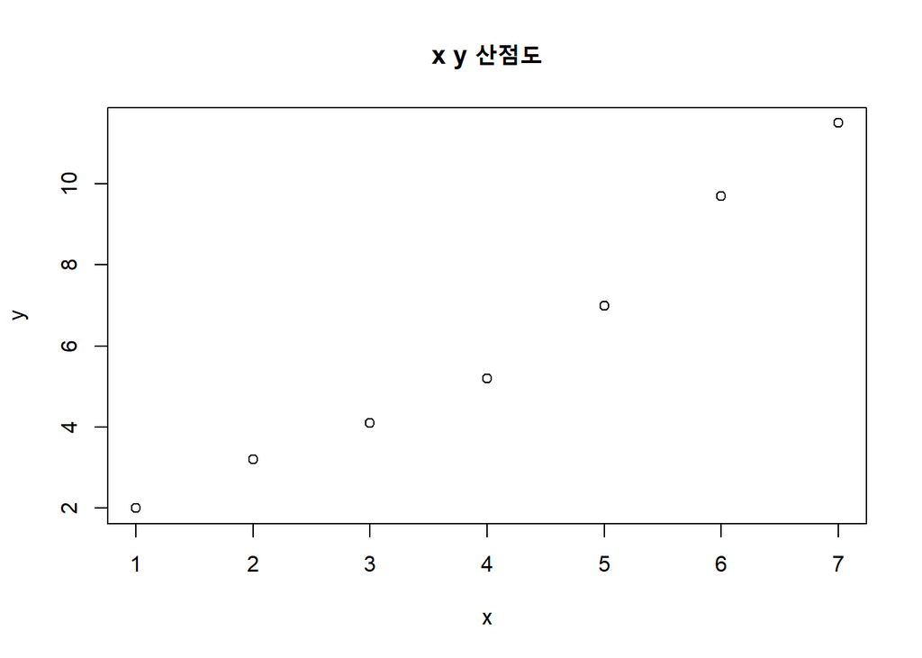

```r
plot(x, y, xlab = "x", ylab = "y", cex = 1.0, main = "x y 산점도")
```

#### 13.6 - (2)

```r
x1 = x
x2 = ifelse(x1 >= 4, 1, 0) ; x2
```

```
## [1] 0 0 0 1 1 1 1
```

```r
x1x2 = (x1 - 4) * x2 ; x1x2
```

```
## [1] 0 0 0 0 1 2 3
```

```r
X = cbind(x1, x1x2)

mult_res = mult_reg(X, y, alpha = 0.05, coeff = TRUE)
```

```
##   요인     제곱합 자유도  평균제곱합      F값  F기각치
## 1 회귀 72.7803297      2 36.39016484 810.1541 6.944272
## 2 잔차  0.1796703      4  0.04491758       NA       NA
## 3   계 72.9600000      6          NA       NA       NA
## SST = 72.96, SSR = 72.7803296703301, SSE = 0.17967032966995
## MSR = 36.390164835165, MSE = 0.0449175824174876
## F_0 = 810.154128442082, F_alpha = 6.94427190999916
```

```r
beta_hat = mult_res$beta_hat ; beta_hat
```

```
##          [,1]
## one  1.049451
## x1   1.020330
## x1x2 1.130769
```

#### 13.6 - (3)

```r
## beta2의 신뢰구간
beta2_hat = beta_hat[3]
var_beta2_hat = mult_res$MSE * solve(mult_res$XtX)[3,3] ; var_beta2_hat
```

```
## [1] 0.02418639
```

```r
t_alpha = qt(0.05, 7 - 3, lower.tail = FALSE)

beta2_CI_lower = beta2_hat - t_alpha * sqrt(var_beta2_hat)
beta2_CI_upper = beta2_hat + t_alpha * sqrt(var_beta2_hat)
beta2_CI_lower ; beta2_CI_upper
```

```
## [1] 0.799225
```

```
## [1] 1.462313
```

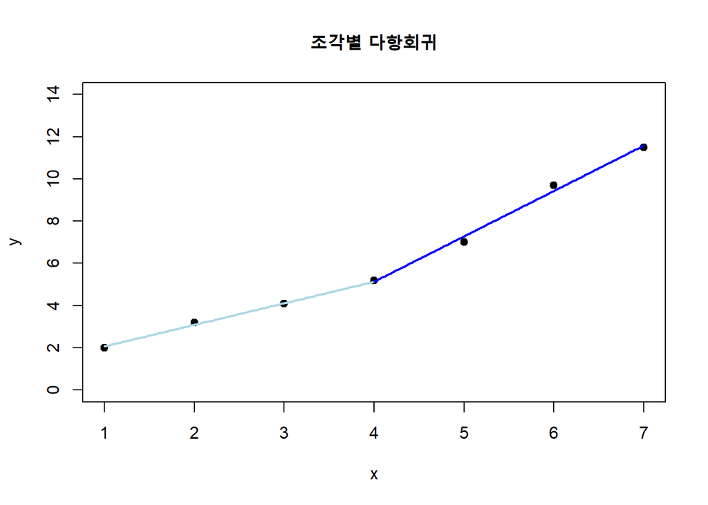

```r
x1 <- seq(1, 4, length.out = 100)
x2 <- seq(4, 7, length.out = 100)

plot(x = x, y = y, xlab = "x", ylab = "y",
     main = "조각별 다항회귀", col = "black", bg = "black", pch = 21, cex = 1, xlim = c(1, 7), ylim = c(0, 14))

## 첫 번째 구간 예측 선 (x in [1,4])
x1 <- seq(1, 4, length.out = 100)
y1 <- mult_res$beta_hat[1] + mult_res$beta_hat[2] * x1
lines(x1, y1, col = "lightblue", lwd = 2)

## 두 번째 구간 예측 선 (x in [4,7])
x2 <- seq(4, 7, length.out = 100)
# y2 <- mult_res$beta_hat[1] + mult_res$beta_hat[2] * x2 + mult_res$beta_hat[3] * (x2 - 4)
y2 <- (mult_res$beta_hat[1] - 4 * mult_res$beta_hat[3]) + (mult_res$beta_hat[2] + mult_res$beta_hat[3]) * x2
lines(x2, y2, col = "blue", lwd = 2)
```

### 13.7

```r
x = c(410, 500, 471, 619, 584, 681, 399, 481, 624, 589)
y = c(0, 1, 0, 1, 0, 1, 0, 1, 1, 1)
X = cbind(x) ; n = length(x) ; one = c(rep(1, n))
```

#### 13.7 - (1)

```r
res = mult_reg(X, y, alpha = 0.05, coeff = TRUE)
```

```
##   요인   제곱합 자유도 평균제곱합      F값  F기각치
## 1 회귀 0.928432      1   0.928432 5.047308 5.317655
## 2 잔차 1.471568      8   0.183946       NA       NA
## 3   계 2.400000      9         NA       NA       NA
## SST = 2.4, SSR = 0.928432045125393, SSE = 1.47156795487461
## MSR = 0.928432045125393, MSE = 0.183945994359326
## F_0 = 5.04730776203675, F_alpha = 5.31765507157871
```

```r
beta_hat = res$beta_hat ; beta_hat
```

```
##            [,1]
## one -1.18171164
## x    0.00332533
```

#### 13.7 - (2)

```r
X = cbind(one, x)
p_hat = X %*% beta_hat
var_p_hat = p_hat * (1 - p_hat) ; var_p_hat = as.vector(var_p_hat)

V_hat = diag(var_p_hat)

V_hat_inv = solve(V_hat)

beta_hat_gls = solve(t(X) %*% V_hat_inv %*% X) %*% t(X) %*% V_hat_inv %*% y
beta_hat_gls
```

```
##             [,1]
## one -2.598496006
## x    0.006223419
```

#### 13.7 - (3)

```r
res$MSE * solve(res$XtX)[2,2]
```

```
## [1] 2.190835e-06
```

```r
solve(t(X) %*% V_hat_inv %*% X)[2,2]
```

```
## [1] 6.58909e-06
```

#### 13.7 - (4)

```r
y_hat = t(c(1, 550)) %*% beta_hat_gls ; y_hat
```

```
##           [,1]
## [1,] 0.8243844
```

### 13.8

```r
data(pbc, package = "survival")
unique(pbc$status)
```

```
## [1] 2 0 1
```

```r
unique(pbc$sex)
```

```
## [1] f m
## Levels: m f
```

```r
unique(pbc$trt)
```

```
## [1]  1  2 NA
```

```r
library(dplyr)
dataset = pbc %>% na.omit() %>% select(status, age, sex, trt)

dim(pbc)
```

```
## [1] 418  20
```

```r
dim(dataset)
```

```
## [1] 276   4
```

```r
unique(dataset$status)
```

```
## [1] 2 0 1
```

```r
dataset = dataset[ dataset$status != 1, ]

dim(dataset)
```

```
## [1] 258   4
```

```r
unique(dataset$status)
```

```
## [1] 2 0
```

```r
unique(dataset$sex)
```

```
## [1] f m
## Levels: m f
```

```r
unique(dataset$trt)
```

```
## [1] 1 2
```

환자의 상태(status) 변수가 반응변수이고, 이때 반응변수는 0(이식을 받지 못한 경우), 2(사망한 경우)의 총 두가지 경우만 있으므로 이진변수로 볼 수 있다. 따라서 2를 1로 바꿔도 무방하다. (즉 1이 사망한 경우를 의미) 성별의 경우 남자는 1, 여자는 0으로 두어도 무방하다. 치료변수의 경우 치료약을 처방받은 경우를 1로 그대로 두고, 위약을 처방받은 경우를 2에서 0으로 바꾸어도 된다.

```r
dataset$status = ifelse(dataset$status == 2, 1, 0)
dataset$sex = ifelse(dataset$sex == "f", 0, 1)
dataset$trt = ifelse(dataset$trt == 2, 0, 1)
```

```r
unique(dataset$status)
```

```
## [1] 1 0
```

```r
unique(dataset$sex)
```

```
## [1] 0 1
```

```r
unique(dataset$trt)
```

```
## [1] 1 0
```

```r
X = dataset[,-c(1)] ; y = dataset[,c(1)]
X = as.matrix(X)
res = mult_reg(X, y, alpha = 0.05, coeff = TRUE)
```

```
##   요인    제곱합 자유도 평균제곱합      F값 F기각치
## 1 회귀  4.708837      3  1.5696123 6.810953 2.64014
## 2 잔차 58.535349    254  0.2304541       NA      NA
## 3   계 63.244186    257         NA       NA      NA
## SST = 63.2441860465115, SSR = 4.70883689880448, SSE = 58.5353491477071
## MSR = 1.56961229960149, MSE = 0.230454130502784
## F_0 = 6.81095320867998, F_alpha = 2.64014026186677
```

```r
beta_hat = res$beta_hat ; beta_hat
```

```
##             [,1]
## one -0.090809983
## age  0.009848776
## sex  0.196810918
## trt  0.001510380
```

우선 적합된 회귀모형은 다음과 같다 :

$$\begin{equation*}
\widehat{\text{status}_i} = -0.0908 + 0.0098 \times \text{age}_i +
0.1968 \times \text{sex}_i + 0.0015 \times \text{trt}_i
\end{equation*}$$

이때 유의수준 $\alpha = 0.05$에서 $F_0 = 6.810953 > F_{\alpha}(3, 254) = 2.64014$ 으로 귀무가설 $H_0 : \beta_1 = \beta_2 = \beta_3 = 0$은 기각된다. 즉 회귀모형은 유의수준 $\alpha = 0.05$에서 유의하다고 할 수 있다.

참고 : 각 회귀계수의 기울기가 유의한지에 대한 검정은 7장의 방법1을 통해서도 할 수 있다.

```r
c1 = c(0, 1, 0, 0) ; c2 = c(0, 0, 1, 0) ; c3 = c(0, 0, 0, 1)
C = rbind(c1, c2, c3) ; m = c(0, 0, 0)
mult_test_res = mult_test(C, m, X, NA, y, NA, alpha = 0.05, method = "one", coef = TRUE)
```

```
## F_0 = 6.81095320868005, F_alpha = 2.64014026186677
```

그런데 반응변수가 가변수이고, 이진변수이므로, 반응변수 `status`에 대하여 베르누이 확률분포를 가정할 수 있다. 따라서

$$\begin{equation*}
E(y_i) = \beta_0 + \beta_1 x_{i1} + \beta_2 x_{i2} + \beta_3 x_{i3} =
p_i
\end{equation*}$$

으로 둘 수 있다. 교재의 내용대로 일반화최소제곱추정방법을 사용하면

```r
n = dim(X)[1] ; one = c(rep(1, n))
p_hat = cbind(one, X) %*% beta_hat
var_p_hat = p_hat * (1 - p_hat) ; var_p_hat = as.vector(var_p_hat)

V_hat = diag(var_p_hat) ; V_hat_inv = solve(V_hat)

beta_hat_gls = solve(t(cbind(one, X)) %*% V_hat_inv %*% cbind(one, X)) %*% t(cbind(one, X)) %*% V_hat_inv %*% y
beta_hat_gls
```

```
##             [,1]
## one -0.071637549
## age  0.009465095
## sex  0.172926742
## trt -0.004044625
```

따라서 이 경우 적합된 회귀모형은 다음과 같다.

$$\begin{equation*}
\widehat{\text{status}_i} = - 0.0716 + 0.0095 \times \text{age}_i +
0.1729 \times \text{sex}_i - 0.0040 \times \text{trt}_i
\end{equation*}$$

각 변수의 교호작용관계가 존재하는지를 확인해보는 절차는 다음과 같다.

```r
age_sex = X[,"age"] * X[,"sex"]
age_trt = X[,"age"] * X[,"trt"]
sex_trt = X[,"sex"] * X[,"trt"]

X = cbind(X, age_sex, age_trt, sex_trt)

c1 = c(0, 0, 0, 0, 1, 0, 0)
c2 = c(0, 0, 0, 0, 0, 1, 0)
c3 = c(0, 0, 0, 0, 0, 0, 1)
C = rbind(c1, c2, c3) ; m = c(0, 0, 0)

mult_test_res = mult_test(C, m, X, NA, y, NA, alpha = 0.05, method = "one", coef = TRUE)
```

```
## F_0 = 1.79838195978301, F_alpha = 2.64056483639326
```